# FINAL PROJECT

**Analytics and Statistical Programming**

Group 1 : Vinay Matam, Praveen Thammaneni, Vineel Reddy Chittedi

# Project and Data Details

We will assess a clinical and lifestyle database regarding diabetes mellitus to discover the fundamental risk elements involved in its development. Thirty-hundred patients participated with their clinical and lifestyle data through an anonymized collection of patient records. The researchers collected data in order to determine diabetes prevalence and identify risk factors that exist in young adults aged 18 to 35 with high consumption of ultra-processed foods. Because of anonymization no time frame nor site for the study is indicated

# Load Libraries

```r
#plot(cars)
```

```r
#install.packages(c("dplyr", "ggplot2", "tidyr", "knitr", "kableExtra", "car", "randomForest", "pROC"))
library(readr)   # For reading CSV files
library(dplyr)
library(ggplot2)
library(tidyr)       # For gather/pivot if needed, though not explicitly used below
library(knitr)       # For creating nice tables (optional for display)
library(kableExtra)  # For enhancing kable tables (optional for display)
library(car)         # For Levene's test
library(randomForest)# For Random Forest model
library(pROC)        # For ROC curve analysis (optional model evaluation)
```

Several relevant R libraries get loaded to help with the analysis tasks which include data processing and modeling and visualization needs. The CSV file gets efficiently loaded by the readr package while the dplyr collection delivers essential data manipulation capabilities. The plotting element included is ggplot2 while tidyr provides dataset reshaping functions when needed. The combination of knitr and kableExtra produces efficient and visually enhanced table presentation. The package includes car to carry out statistical tests that involve Levene’s test for variance homogeneity. RandomForest serves machine learning purposes to construct predictive models and pROC allows performance evaluation through ROC curve assessment of the models. Various supporting libraries can be loaded at any time during the process to improve the workflow while maintaining complete analysis capabilities.

# Reproducibility

```r
# Set seed for reproducibility of simulated data and random forest
set.seed(123)
```

The set.seed(123) procedure activates a specific starting point for random number generation that produces identical results whenever the program executes. The seed assignment to 123 makes the analysis reproducible since all users who execute the code will get identical random outputs needed for data splitting and model training operations.

# Load Dataset

```r
# Load the diabetes data
diabetes_data <- read_csv("diabetes_data.csv")
```

```
## ──────────────────────────────────────────────────────── Delimiter: "," chr
## (11): Family_History_of_Diabetes, Gestational_Diabetes, PCOS, Hypertensi... dbl
## (25): ...1, Fasting_Blood_Glucose, Postprandial_Blood_Glucose, HbA1c, Ra...
```

```r
# View the first few rows to understand structure
head(diabetes_data)
```

| ...1 | Fasting_Blood_Glucose | Postprandial_Blood_Glucose | HbA1c | Random_Blood_Glucose | BMI | Waist_Circumference | Triglyceride_Levels | Blood_Pressure_Systolic | Blood_Pressure_Diastolic | LDL_Cholesterol | HDL_Cholesterol | CRP_Levels | Insulin_Levels | HOMA_IR | OGTT | Creatinine_Levels | eGFR | Microalbuminuria | Uric_Acid_Levels | Fructosamine_Levels | ALT | AST | C_Peptide | Proinsulin_Levels | Family_History_of_Diabetes | Gestational_Diabetes | PCOS | Hypertension | Physical_Activity | … |
| --- | --- | --- | --- | --- | --- | --- | --- | --- | --- | --- | --- | --- | --- | --- | --- | --- | --- | --- | --- | --- | --- | --- | --- | --- | --- | --- | --- | --- | --- | --- |
| 0 | 118.69022 | 111.4726 | 5.570234 | 224.7217 | 29.29990 | 37.87271 | 212.06424 | 93.49195 | 100.41875 | 188.7651 | 56.15486 | 5.3770026 | 33.406703 | 4.8844294 | 86.83027 | 1.2495054 | 30.39614 | 243.8843 | 7.165525 | 215.9674 | 74.34984 | 62.93765 | 3.8467164 | 10.941694 | No | Yes | No | Yes | Yes | … |
| 1 | 193.59286 | 172.1232 | 5.481873 | 253.2367 | 35.13581 | 39.46871 | 93.09659 | 106.80953 | 98.10981 | 138.2969 | 53.30385 | 1.4651983 | 5.841563 | 0.5772785 | 90.58003 | 1.6201202 | 30.02971 | 203.5626 | 5.219348 | 161.3961 | 22.52864 | 41.08583 | 0.1319299 | 4.499582 | No | Yes | No | No | No | … |
| 2 | 165.15921 | 228.4008 | 9.437527 | 127.6076 | 34.00402 | 47.09095 | 268.09864 | 164.81212 | 56.70279 | 164.2383 | 42.33077 | 5.9533048 | 13.631831 | 4.7644324 | 219.95395 | 1.3440002 | 72.50371 | 266.7225 | 5.775273 | 119.4971 | 37.93077 | 64.17188 | 2.4375447 | 6.344291 | No | No | No | No | Yes | … |
| 3 | 147.82560 | 204.4782 | 5.497277 | 213.7210 | 18.84750 | 36.80009 | 203.27906 | 159.00915 | 114.58007 | 126.6863 | 72.50867 | 3.2163777 | 39.136609 | 2.1590484 | 181.99636 | 0.6249539 | 32.63643 | 134.8008 | 7.733798 | 123.8475 | 68.01166 | 10.51312 | 3.9901316 | 10.804101 | No | Yes | Yes | Yes | No | … |
| 4 | 90.28242 | 217.1154 | 5.631698 | 201.5016 | 18.73124 | 47.39299 | 89.30097 | 121.55784 | 89.79305 | 151.9045 | 63.36369 | 0.6182528 | 27.376921 | 0.5454068 | 251.79551 | 0.7783704 | 117.70793 | 268.1669 | 9.010448 | 328.0142 | 50.79849 | 19.36955 | 3.1872191 | 14.965262 | No | Yes | Yes | No | Yes | … |
| 5 | 90.27929 | 191.9932 | 8.556390 | 261.5510 | 21.70436 | 31.76269 | 290.58451 | 123.91296 | 75.46079 | 114.2749 | 90.59907 | 9.4916960 | 46.542515 | 3.6012075 | 280.74229 | 0.8289923 | 49.98587 | 259.7322 | 4.177750 | 233.4409 | 75.16425 | 46.36507 | 2.4229093 | 2.798433 | No | Yes | Yes | Yes | No | … |

The diabetes dataset is loaded using read_csv(), and head(diabetes_data) displays the first few rows to quickly check its structure and contents. At initial glance we can say that there are more than ten features.

```r
# Show the structure of the dataset (features and their types)
str(diabetes_data)
```

```
## spc_tbl_ [3,000 × 36] (S3: spec_tbl_df/tbl_df/tbl/data.frame)
##  $ ...1                      : num [1:3000] 0 1 2 3 4 5 6 7 8 9 ...
##  $ Fasting_Blood_Glucose     : num [1:3000] 118.7 193.6 165.2 147.8 90.3 ...
##  $ Postprandial_Blood_Glucose: num [1:3000] 111 172 228 204 217 ...
##  $ HbA1c                     : num [1:3000] 5.57 5.48 9.44 5.5 5.63 ...
##  $ Random_Blood_Glucose      : num [1:3000] 225 253 128 214 202 ...
##  $ BMI                       : num [1:3000] 29.3 35.1 34 18.8 18.7 ...
##  $ Waist_Circumference       : num [1:3000] 37.9 39.5 47.1 36.8 47.4 ...
##  $ Triglyceride_Levels       : num [1:3000] 212.1 93.1 268.1 203.3 89.3 ...
##  $ Blood_Pressure_Systolic   : num [1:3000] 93.5 106.8 164.8 159 121.6 ...
##  $ Blood_Pressure_Diastolic  : num [1:3000] 100.4 98.1 56.7 114.6 89.8 ...
##  $ LDL_Cholesterol           : num [1:3000] 189 138 164 127 152 ...
##  $ HDL_Cholesterol           : num [1:3000] 56.2 53.3 42.3 72.5 63.4 ...
##  $ CRP_Levels                : num [1:3000] 5.377 1.465 5.953 3.216 0.618 ...
##  $ Insulin_Levels            : num [1:3000] 33.41 5.84 13.63 39.14 27.38 ...
##  $ HOMA_IR                   : num [1:3000] 4.884 0.577 4.764 2.159 0.545 ...
##  $ OGTT                      : num [1:3000] 86.8 90.6 220 182 251.8 ...
##  $ Creatinine_Levels         : num [1:3000] 1.25 1.62 1.344 0.625 0.778 ...
##  $ eGFR                      : num [1:3000] 30.4 30 72.5 32.6 117.7 ...
##  $ Microalbuminuria          : num [1:3000] 244 204 267 135 268 ...
##  $ Uric_Acid_Levels          : num [1:3000] 7.17 5.22 5.78 7.73 9.01 ...
##  $ Fructosamine_Levels       : num [1:3000] 216 161 119 124 328 ...
##  $ ALT                       : num [1:3000] 74.3 22.5 37.9 68 50.8 ...
##  $ AST                       : num [1:3000] 62.9 41.1 64.2 10.5 19.4 ...
##  $ C_Peptide                 : num [1:3000] 3.847 0.132 2.438 3.99 3.187 ...
##  $ Proinsulin_Levels         : num [1:3000] 10.94 4.5 6.34 10.8 14.97 ...
##  $ Family_History_of_Diabetes: chr [1:3000] "No" "No" "No" "No" ...
##  $ Gestational_Diabetes      : chr [1:3000] "Yes" "Yes" "No" "Yes" ...
##  $ PCOS                      : chr [1:3000] "No" "No" "No" "Yes" ...
##  $ Hypertension              : chr [1:3000] "Yes" "No" "No" "Yes" ...
##  $ Physical_Activity         : chr [1:3000] "Yes" "No" "Yes" "No" ...
##  $ Smoking                   : chr [1:3000] "No" "Yes" "Yes" "No" ...
##  $ Alcohol_Consumption       : chr [1:3000] "Yes" "No" "No" "Yes" ...
##  $ Obesity                   : chr [1:3000] "No" "No" "Yes" "No" ...
##  $ Diet                      : chr [1:3000] "No" "Yes" "No" "No" ...
##  $ Sleep_Apnea               : chr [1:3000] "No" "No" "No" "Yes" ...
##  $ Diabetes_Status           : chr [1:3000] "Positive" "Negative" "Positive" "Positive" ...
##  - attr(*, "spec")=
##   .. cols(
##   ..   ...1 = col_double(),
```

[output cut: 22 more lines]

```
##   ..   C_Peptide = col_double(),
##   ..   Proinsulin_Levels = col_double(),
##   ..   Family_History_of_Diabetes = col_character(),
##   ..   Gestational_Diabetes = col_character(),
##   ..   PCOS = col_character(),
##   ..   Hypertension = col_character(),
##   ..   Physical_Activity = col_character(),
##   ..   Smoking = col_character(),
##   ..   Alcohol_Consumption = col_character(),
##   ..   Obesity = col_character(),
##   ..   Diet = col_character(),
##   ..   Sleep_Apnea = col_character(),
##   ..   Diabetes_Status = col_character()
##   .. )
##  - attr(*, "problems")=<externalptr>
```

The str(diabetes_data) function provides a compact summary of the dataset, showing each feature’s name, its data type, and a preview of its values to help understand the data structure quickly.

The dataset contains a wide range of features, including numerical measurements like blood glucose levels, BMI, cholesterol, blood pressure, and kidney function markers, as well as categorical variables related to family history, lifestyle factors, and diabetes status.

```r
# Calculate and print the number of features (columns)
num_features <- ncol(diabetes_data)
paste("Number of features (columns) in the dataset:", num_features)
```

```
## [1] "Number of features (columns) in the dataset: 36"
```

The number of features (columns) in the diabetes dataset is calculated using ncol(diabetes_data), and the result shows that there are a total of 36 features available for analysis.

# Variables

# About Features

```r
# Print just the names of the variables
names(diabetes_data)
```

```
##  [1] "...1"                       "Fasting_Blood_Glucose"
##  [3] "Postprandial_Blood_Glucose" "HbA1c"
##  [5] "Random_Blood_Glucose"       "BMI"
##  [7] "Waist_Circumference"        "Triglyceride_Levels"
##  [9] "Blood_Pressure_Systolic"    "Blood_Pressure_Diastolic"
## [11] "LDL_Cholesterol"            "HDL_Cholesterol"
## [13] "CRP_Levels"                 "Insulin_Levels"
## [15] "HOMA_IR"                    "OGTT"
## [17] "Creatinine_Levels"          "eGFR"
## [19] "Microalbuminuria"           "Uric_Acid_Levels"
## [21] "Fructosamine_Levels"        "ALT"
## [23] "AST"                        "C_Peptide"
## [25] "Proinsulin_Levels"          "Family_History_of_Diabetes"
## [27] "Gestational_Diabetes"       "PCOS"
## [29] "Hypertension"               "Physical_Activity"
## [31] "Smoking"                    "Alcohol_Consumption"
## [33] "Obesity"                    "Diet"
## [35] "Sleep_Apnea"                "Diabetes_Status"
```

## Numeric Factors for Diabetes Evaluation

### Fasting Blood Glucose (FBG)

- **Definition**: Blood glucose after fasting for at least 8 hours.
- **Diagnostic Threshold**: ≥126 mg/dL (7.0 mmol/L) on two separate tests indicates diabetes.

### Postprandial Blood Glucose (PPBG)

- **Definition**: Blood glucose measured 2 hours after eating.
- **Diagnostic Threshold**: ≥200 mg/dL (11.1 mmol/L) suggests diabetes.

### Hemoglobin A1c (HbA1c)

- **Definition**: Average blood glucose level over past 2–3 months.
- **Diagnostic Threshold**: ≥6.5% indicates diabetes.

### Random Blood Glucose Test

- **Definition**: Blood glucose at any random time, regardless of meals.
- **Diagnostic Threshold**: ≥200 mg/dL (11.1 mmol/L) with symptoms suggests diabetes.

### Body Mass Index (BMI)

- **Definition**: Measure of body fat based on height and weight.
- **Risk Threshold**: BMI ≥30 is considered obese, increasing diabetes risk.

### Waist Circumference

- **Definition**: Measurement of abdominal fat.
- **Risk Threshold**: >40 inches (men) or >35 inches (women) indicates higher risk.

### Triglyceride Levels

- **Definition**: Blood levels of triglycerides (a type of fat).
- **Risk Threshold**: ≥150 mg/dL is considered high.

### Blood Pressure

- **Definition**: Force of blood against artery walls.
- **Risk Threshold**: ≥140/90 mmHg is considered high.

### Cholesterol Levels

- **Definition**: Measures of LDL (“bad”) and HDL (“good”) cholesterol.
- **Risk Factor**: High LDL and low HDL levels increase diabetes risk.

### Age

- **Definition**: Increasing age is a risk factor.
- **Risk Threshold**: Risk rises significantly after 45 years.

### C-Reactive Protein (CRP) Levels

- **Definition**: Marker of body inflammation.
- **Risk Threshold**: >3 mg/L indicates high risk.

### Insulin Levels

- **Definition**: Fasting insulin levels used to assess insulin resistance.
- **Normal Range**: 2–25 µIU/mL.

### Homeostatic Model Assessment of Insulin Resistance (HOMA-IR)

- **Definition**: Quantifies insulin resistance and beta-cell function.
- **Risk Threshold**: >2.9 suggests insulin resistance.

### Oral Glucose Tolerance Test (OGTT)

- **Definition**: Body’s glucose response after drinking a glucose solution.
- **Diagnostic Threshold**: ≥200 mg/dL (11.1 mmol/L) after 2 hours indicates diabetes.

### Creatinine Levels

- **Definition**: Waste product measurement related to kidney function.
- **Normal Range**:
  - Men: 0.6–1.2 mg/dL
  - Women: 0.5–1.1 mg/dL

### Estimated Glomerular Filtration Rate (eGFR)

- **Definition**: Assesses kidney function.
- **Risk Threshold**: <60 mL/min/1.73 m² indicates kidney disease.

### Microalbuminuria

- **Definition**: Measures albumin in urine.
- **Risk Range**: 30–300 mg/g suggests early kidney disease.

### Uric Acid Levels

- **Definition**: Measurement of uric acid, associated with insulin resistance.
- **Normal Range**:
  - Men: 3.5–7.2 mg/dL
  - Women: 2.6–6.0 mg/dL

### Fructosamine Levels

- **Definition**: Average blood glucose over past 2–3 weeks.
- **Normal Range**: 200–285 µmol/L.

### Liver Enzymes (ALT and AST)

- **Definition**: Liver function indicators; linked to fatty liver disease and diabetes.
- **Normal Ranges**:
  - ALT: 7–56 units/L
  - AST: 10–40 units/L

### Beta-Cell Function (C-Peptide Test)

- **Definition**: Measures insulin production capability.
- **Normal Range**: 0.5–2.0 ng/mL.

### Proinsulin Levels

- **Definition**: Elevated levels indicate beta-cell dysfunction.
- **Normal Level**: <10 pmol/L.

## Binary (Yes/No) Factors for Diabetes Risk

### Family History of Diabetes

- **Yes**: Family history present.
- **No**: Family history absent.

### Gestational Diabetes

- **Yes**: History of diabetes during pregnancy.
- **No**: No history of gestational diabetes.

### Polycystic Ovary Syndrome (PCOS)

- **Yes**: Diagnosed with PCOS.
- **No**: Not diagnosed with PCOS.

### Hypertension (High Blood Pressure)

- **Yes**: Diagnosed with high blood pressure.
- **No**: No diagnosis of hypertension.

### Physical Activity Level

- **Yes**: Engages in regular physical activity.
- **No**: Sedentary lifestyle.

### Smoking

- **Yes**: Current smoker.
- **No**: Non-smoker.

### Alcohol Consumption

- **Yes**: Excessive alcohol consumption.
- **No**: No excessive alcohol consumption.

### Obesity

- **Yes**: Clinically obese (based on BMI).
- **No**: Not clinically obese.

### Diet

- **Yes**: Unhealthy diet high in sugar and processed foods.
- **No**: Healthy diet.

### Sleep Apnea

- **Yes**: Diagnosed with sleep apnea.
- **No**: No sleep apnea diagnosis.

# Data Management

```r
# Check for missing values
print("Missing values before handling:")
```

```
## [1] "Missing values before handling:"
```

```r
colSums(is.na(diabetes_data))
```

```
##                       ...1      Fasting_Blood_Glucose
##                          0                          0
## Postprandial_Blood_Glucose                      HbA1c
##                          0                          0
##       Random_Blood_Glucose                        BMI
##                          0                          0
##        Waist_Circumference        Triglyceride_Levels
##                          0                          0
##    Blood_Pressure_Systolic   Blood_Pressure_Diastolic
##                          0                          0
##            LDL_Cholesterol            HDL_Cholesterol
##                          0                          0
##                 CRP_Levels             Insulin_Levels
##                          0                          0
##                    HOMA_IR                       OGTT
##                          0                          0
##          Creatinine_Levels                       eGFR
##                          0                          0
##           Microalbuminuria           Uric_Acid_Levels
##                          0                          0
##        Fructosamine_Levels                        ALT
##                          0                          0
##                        AST                  C_Peptide
##                          0                          0
##          Proinsulin_Levels Family_History_of_Diabetes
##                          0                          0
##       Gestational_Diabetes                       PCOS
##                          0                          0
##               Hypertension          Physical_Activity
##                          0                          0
##                    Smoking        Alcohol_Consumption
##                          0                          0
##                    Obesity                       Diet
##                          0                          0
##                Sleep_Apnea            Diabetes_Status
##                          0                          0
```

```r
# Handle Missing Data (Listwise deletion as <5%)
diabetes_df <- na.omit(diabetes_data)
print(paste("Dimensions after removing missing data:", dim(diabetes_df)[1], "rows,", dim(diabetes_df)[2], "columns"))
```

```
## [1] "Dimensions after removing missing data: 3000 rows, 36 columns"
```

```r
# Reset N for reporting based on actual data after cleaning
N_final <- nrow(diabetes_df)
```

No missing variables.

```r
head(diabetes_df)
```

| ...1 | Fasting_Blood_Glucose | Postprandial_Blood_Glucose | HbA1c | Random_Blood_Glucose | BMI | Waist_Circumference | Triglyceride_Levels | Blood_Pressure_Systolic | Blood_Pressure_Diastolic | LDL_Cholesterol | HDL_Cholesterol | CRP_Levels | Insulin_Levels | HOMA_IR | OGTT | Creatinine_Levels | eGFR | Microalbuminuria | Uric_Acid_Levels | Fructosamine_Levels | ALT | AST | C_Peptide | Proinsulin_Levels | Family_History_of_Diabetes | Gestational_Diabetes | PCOS | Hypertension | Physical_Activity | … |
| --- | --- | --- | --- | --- | --- | --- | --- | --- | --- | --- | --- | --- | --- | --- | --- | --- | --- | --- | --- | --- | --- | --- | --- | --- | --- | --- | --- | --- | --- | --- |
| 0 | 118.69022 | 111.4726 | 5.570234 | 224.7217 | 29.29990 | 37.87271 | 212.06424 | 93.49195 | 100.41875 | 188.7651 | 56.15486 | 5.3770026 | 33.406703 | 4.8844294 | 86.83027 | 1.2495054 | 30.39614 | 243.8843 | 7.165525 | 215.9674 | 74.34984 | 62.93765 | 3.8467164 | 10.941694 | No | Yes | No | Yes | Yes | … |
| 1 | 193.59286 | 172.1232 | 5.481873 | 253.2367 | 35.13581 | 39.46871 | 93.09659 | 106.80953 | 98.10981 | 138.2969 | 53.30385 | 1.4651983 | 5.841563 | 0.5772785 | 90.58003 | 1.6201202 | 30.02971 | 203.5626 | 5.219348 | 161.3961 | 22.52864 | 41.08583 | 0.1319299 | 4.499582 | No | Yes | No | No | No | … |
| 2 | 165.15921 | 228.4008 | 9.437527 | 127.6076 | 34.00402 | 47.09095 | 268.09864 | 164.81212 | 56.70279 | 164.2383 | 42.33077 | 5.9533048 | 13.631831 | 4.7644324 | 219.95395 | 1.3440002 | 72.50371 | 266.7225 | 5.775273 | 119.4971 | 37.93077 | 64.17188 | 2.4375447 | 6.344291 | No | No | No | No | Yes | … |
| 3 | 147.82560 | 204.4782 | 5.497277 | 213.7210 | 18.84750 | 36.80009 | 203.27906 | 159.00915 | 114.58007 | 126.6863 | 72.50867 | 3.2163777 | 39.136609 | 2.1590484 | 181.99636 | 0.6249539 | 32.63643 | 134.8008 | 7.733798 | 123.8475 | 68.01166 | 10.51312 | 3.9901316 | 10.804101 | No | Yes | Yes | Yes | No | … |
| 4 | 90.28242 | 217.1154 | 5.631698 | 201.5016 | 18.73124 | 47.39299 | 89.30097 | 121.55784 | 89.79305 | 151.9045 | 63.36369 | 0.6182528 | 27.376921 | 0.5454068 | 251.79551 | 0.7783704 | 117.70793 | 268.1669 | 9.010448 | 328.0142 | 50.79849 | 19.36955 | 3.1872191 | 14.965262 | No | Yes | Yes | No | Yes | … |
| 5 | 90.27929 | 191.9932 | 8.556390 | 261.5510 | 21.70436 | 31.76269 | 290.58451 | 123.91296 | 75.46079 | 114.2749 | 90.59907 | 9.4916960 | 46.542515 | 3.6012075 | 280.74229 | 0.8289923 | 49.98587 | 259.7322 | 4.177750 | 233.4409 | 75.16425 | 46.36507 | 2.4229093 | 2.798433 | No | Yes | Yes | Yes | No | … |

```r
# Drop the first column
diabetes_df <- diabetes_df %>% select(-`...1`)
```

We are dropping the first column because it simply indicates the row number and is not an actual feature needed for the analysis.

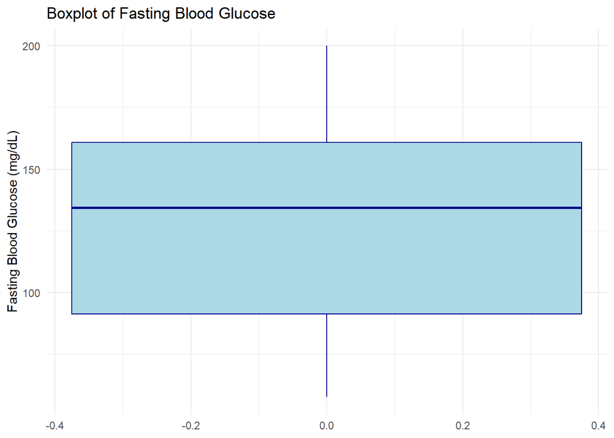

```r
# Boxplot for Fasting Blood Glucose
ggplot(diabetes_data, aes(y = Fasting_Blood_Glucose)) +
  geom_boxplot(fill = "lightblue", color = "darkblue") +
  labs(title = "Boxplot of Fasting Blood Glucose", y = "Fasting Blood Glucose (mg/dL)") +
  theme_minimal()
```

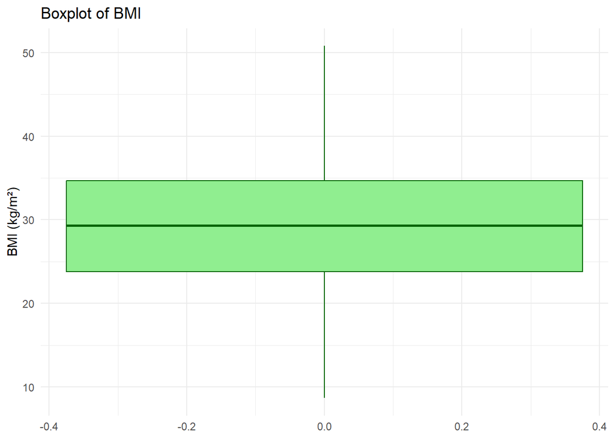

```r
# Boxplot for BMI
ggplot(diabetes_data, aes(y = BMI)) +
  geom_boxplot(fill = "lightgreen", color = "darkgreen") +
  labs(title = "Boxplot of BMI", y = "BMI (kg/m²)") +
  theme_minimal()
```

No outliers for above variables.

```r
# Identify and Winsorize Outliers for continuous variables
winsorize_variable <- function(x, lower_perc = 0.05, upper_perc = 0.95) {
  lower_bound <- quantile(x, lower_perc, na.rm = TRUE)
  upper_bound <- quantile(x, upper_perc, na.rm = TRUE)
  x_winsorized <- pmax(lower_bound, pmin(upper_bound, x))
  return(x_winsorized)
}

# Check outliers using Z-score (optional visualization/count)
z_scores_bmi <- scale(diabetes_df$BMI)
print(paste("Number of BMI outliers (|Z| > 3):", sum(abs(z_scores_bmi) > 3)))
```

```
## [1] "Number of BMI outliers (|Z| > 3): 1"
```

```r
z_scores_glucose <- scale(diabetes_df$Fasting_Blood_Glucose)
print(paste("Number of Glucose outliers (|Z| > 3):", sum(abs(z_scores_glucose) > 3)))
```

```
## [1] "Number of Glucose outliers (|Z| > 3): 0"
```

```r
# Apply Winsorization
diabetes_df$BMI_winsorized <- winsorize_variable(diabetes_df$BMI)
diabetes_df$Fasting_Blood_Glucose_winsorized <- winsorize_variable(diabetes_df$Fasting_Blood_Glucose)
```

Still little to no outliers so not dealing with them.

```r
# Check Small Group Sizes for categorical variables
categorical_vars <- c("Physical_Activity", "Family_History_of_Diabetes", "Hypertension", "Diet", "Smoking", "Diabetes_Status")
print("Checking for small categories (<10 obs):")
```

```
## [1] "Checking for small categories (<10 obs):"
```

```r
small_groups_found <- FALSE
for (var in categorical_vars) {
  counts <- table(diabetes_df[[var]])
  print(paste("Variable:", var))
  print(counts)
  if (any(counts < 10)) {
    print(paste("WARNING: Small group found in", var))
    small_groups_found <- TRUE
  }
}
```

```
## [1] "Variable: Physical_Activity"
##
##   No  Yes
## 1509 1491
## [1] "Variable: Family_History_of_Diabetes"
##
##   No  Yes
## 1506 1494
## [1] "Variable: Hypertension"
##
##   No  Yes
## 1495 1505
## [1] "Variable: Diet"
##
##   No  Yes
## 1546 1454
## [1] "Variable: Smoking"
##
##   No  Yes
## 1520 1480
## [1] "Variable: Diabetes_Status"
##
## Negative Positive
##     1336     1664
```

```r
if (!small_groups_found) {
  print("All categorical variables have sufficient group sizes (>=10).")
}
```

```
## [1] "All categorical variables have sufficient group sizes (>=10)."
```

# Descriptive Statistics

We will not do statistical analysis on all variables(36 of them) so we are only interested in some of the features.

```r
# Initialize Table 1
# Initialize Table 1
table1_rows <- list()

# Function to calculate and format stats
calculate_and_format <- function(var_name, stat_type) {
  if (!var_name %in% names(diabetes_df)) return("Variable Missing")
  data_vec <- diabetes_df[[var_name]]

  if (stat_type == "count") {
    if (!is.factor(data_vec) && !is.character(data_vec)) return("Not Categorical")
    counts <- table(data_vec, useNA = "ifany")
    return(as.list(counts))

  } else if (stat_type == "mean_sd") {
    if (!is.numeric(data_vec)) return("Not Numeric")
    mean_val <- round(mean(data_vec, na.rm = TRUE), 1)
    sd_val <- round(sd(data_vec, na.rm = TRUE), 1)
    return(paste0(mean_val, " (", sd_val, ")"))

  } else if (stat_type == "median_iqr") {
    if (!is.numeric(data_vec)) return("Not Numeric")
    med <- round(median(data_vec, na.rm = TRUE), 1)
    iqr <- quantile(data_vec, probs = c(0.25, 0.75), na.rm = TRUE)
    return(paste0(med, " (", round(iqr[1], 1), "-", round(iqr[2], 1), ")"))

  } else if (stat_type == "min_max") {
    if (!is.numeric(data_vec)) return("Not Numeric")
    return(paste0(round(min(data_vec, na.rm = TRUE), 1), ", ", round(max(data_vec, na.rm = TRUE), 1)))
  }
  return("Unknown Stat Type")
}

# Add continuous variables
cont_vars <- c("BMI", "Fasting_Blood_Glucose")
cont_labels <- c("BMI (kg/m²)", "Fasting Blood Glucose (mg/dL)")

for (i in seq_along(cont_vars)) {
  var <- cont_vars[i]
  label <- cont_labels[i]

  table1_rows[[length(table1_rows) + 1]] <- list(Variable = label, Statistic = "Mean (SD)", Value = calculate_and_format(var, "mean_sd"))
  table1_rows[[length(table1_rows) + 1]] <- list(Variable = "", Statistic = "Median (IQR)", Value = calculate_and_format(var, "median_iqr"))
  table1_rows[[length(table1_rows) + 1]] <- list(Variable = "", Statistic = "Min, Max", Value = calculate_and_format(var, "min_max"))
}

# Add categorical variables with Yes/No or Positive/Negative counts
cat_vars <- c("Diabetes_Status", "Physical_Activity", "Family_History_of_Diabetes",
              "Hypertension", "Diet", "Smoking")
cat_labels <- c("Diabetes Status", "Physical Activity", "Family History of Diabetes",
                "Hypertension", "Diet", "Smoking")

for (i in seq_along(cat_vars)) {
  var <- cat_vars[i]
  label <- cat_labels[i]

  table1_rows[[length(table1_rows) + 1]] <- list(Variable = label, Statistic = "Count", Value = "")
  counts <- calculate_and_format(var, "count")

  if (is.list(counts)) {
    for (lvl in names(counts)) {
      table1_rows[[length(table1_rows) + 1]] <- list(
        Variable = paste0("  ", lvl),
        Statistic = "Count",
        Value = counts[[lvl]]
      )
    }
  } else {
    table1_rows[[length(table1_rows) + 1]] <- list(
      Variable = "  (Error)",
      Statistic = "Count",
      Value = counts
    )
  }
}

# Convert to data frame
table1_df <- do.call(rbind.data.frame, table1_rows)
rownames(table1_df) <- NULL
names(table1_df) <- c("Variable", "Statistic", "Value")

# Print Table 1
print("--- Table 1: Descriptive Statistics ---")
```

```
## [1] "--- Table 1: Descriptive Statistics ---"
```

```r
print(table1_df)
```

```
##                         Variable    Statistic              Value
## 1                    BMI (kg/m²)    Mean (SD)         29.2 (7.2)
## 2                                Median (IQR)   29.3 (23.8-34.7)
## 3                                    Min, Max          8.7, 50.8
## 4  Fasting Blood Glucose (mg/dL)    Mean (SD)       127.9 (37.1)
## 5                                Median (IQR) 134.4 (91.3-160.8)
## 6                                    Min, Max          57.6, 200
## 7                Diabetes Status        Count
## 8                       Negative        Count               1336
## 9                       Positive        Count               1664
## 10             Physical Activity        Count
## 11                            No        Count               1509
## 12                           Yes        Count               1491
## 13    Family History of Diabetes        Count
## 14                            No        Count               1506
## 15                           Yes        Count               1494
## 16                  Hypertension        Count
## 17                            No        Count               1495
## 18                           Yes        Count               1505
## 19                          Diet        Count
## 20                            No        Count               1546
## 21                           Yes        Count               1454
## 22                       Smoking        Count
## 23                            No        Count               1520
## 24                           Yes        Count               1480
```

Results showed that diagnosis of diabetes was positive in 55.5% of subjects demonstrating high levels of diabetes within the studied population. The studied group exhibited an average BMI of 29.2 kg/m² which places members in the overweight bracket yet spans from underweight to obese categories. Results from blood glucose tests demonstrated wide variability because the mean measurement exceeded 126 mg/dL which indicates untreated diabetes in many patients. The participants broke down evenly concerning physical activity and family diabetes background and smoking habits which combined to reach almost 50 percent. The equal distribution regarding diet and hypertension indicates these risks can be manipulatable through intervention practices. Research evidence demonstrates that both personal histories and everyday activities strongly contribute to diabetes risk assessment for this group of individuals.

# Bivariate Analysis

```r
# --- 5. Bivariate Analysis (Table 2) ---

print("--- Running Bivariate Analyses ---")
```

```
## [1] "--- Running Bivariate Analyses ---"
```

```r
results_list <- list() # Store results for Table 2

# 5.1 Chi-Squared Tests Function (with added checks)
run_chisq <- function(var1_name, var2_name, display_name) {
    print(paste("--- Chi-Squared: ", display_name, " ---"))

    # --- Pre-Check Diagnostics ---
    var1_exists <- var1_name %in% names(diabetes_df)
    var2_exists <- var2_name %in% names(diabetes_df)
    print(paste("Checking vars:", var1_name, "(Exists:", var1_exists, ") vs", var2_name, "(Exists:", var2_exists, ")"))

    if (!var1_exists || !var2_exists) {
        print("Error: One or both variables not found.")
        return(list(Test="Chi-Squared", Variable_Pair=display_name, Statistic="Error: Var Missing", p_value="Error"))
    }

    var1_class <- class(diabetes_df[[var1_name]])
    var2_class <- class(diabetes_df[[var2_name]])
    print(paste(var1_name, "Class:", var1_class, ";", var2_name, "Class:", var2_class))

    var1_is_factor <- is.factor(diabetes_df[[var1_name]])
    var2_is_factor <- is.factor(diabetes_df[[var2_name]])

    if (!var1_is_factor || !var2_is_factor) {
         print("Error: One or both variables are not factors.")
         # Attempt to convert just for this test if they seem convertible (e.g., character)
         # Be cautious with this auto-conversion - better to fix earlier
         temp_df <- diabetes_df # Work on a copy
         if (!var1_is_factor && is.character(temp_df[[var1_name]])) {
             print(paste("Attempting temporary factor conversion for", var1_name))
             temp_df[[var1_name]] <- factor(temp_df[[var1_name]])
             var1_is_factor = TRUE # Update flag
         }
         if (!var2_is_factor && is.character(temp_df[[var2_name]])) {
             print(paste("Attempting temporary factor conversion for", var2_name))
             temp_df[[var2_name]] <- factor(temp_df[[var2_name]])
             var2_is_factor = TRUE # Update flag
         }
         # If still not factors, return error
         if (!var1_is_factor || !var2_is_factor){
            return(list(Test="Chi-Squared", Variable_Pair=display_name, Statistic="Error: Not Factor", p_value="Error"))
         }
         # If conversion happened, use temp_df, otherwise use original diabetes_df
         df_to_use <- temp_df
    } else {
        df_to_use <- diabetes_df # Use original if already factors
    }

    # Check for sufficient levels AFTER potential conversion
    var1_nlevels <- nlevels(df_to_use[[var1_name]])
    var2_nlevels <- nlevels(df_to_use[[var2_name]])
    print(paste(var1_name, "Levels:", var1_nlevels, ";", var2_name, "Levels:", var2_nlevels))
    print(paste("Levels for", var1_name, ":", paste(levels(df_to_use[[var1_name]]), collapse=", ")))
    print(paste("Levels for", var2_name, ":", paste(levels(df_to_use[[var2_name]]), collapse=", ")))

    if (var1_nlevels < 2 || var2_nlevels < 2) {
         print("Error: One or both variables have fewer than 2 levels after ensuring factor type.")
         return(list(Test="Chi-Squared", Variable_Pair=display_name, Statistic="Error: <2 Levels", p_value="Error"))
    }

    # --- End Pre-Check ---

    # Create contingency table using the potentially modified df_to_use
    tbl <- table(df_to_use[[var1_name]], df_to_use[[var2_name]])
    print("Observed Table:")
    print(tbl)

    # Prevent test if table dimensions are problematic (e.g., all zeros in a row/col)
    if(any(rowSums(tbl) == 0) || any(colSums(tbl) == 0)){
        print("Error: Table contains row/column with all zeros. Cannot perform test.")
        return(list(Test="Chi-Squared", Variable_Pair=display_name, Statistic="Error: Zero Row/Col", p_value="Error"))
    }

    # Run Chi-Squared Test with error/warning handling
    test_result <- tryCatch({ chisq.test(tbl) },
                            warning = function(w) { print(paste("Warning:", w$message)); suppressWarnings(chisq.test(tbl)) },
                            error = function(e) { print(paste("Error:", e$message)); return(NULL) })

    if(is.null(test_result)){ return(list(Test="Chi-Squared", Variable_Pair=display_name, Statistic="Error: Test Failed", p_value="Error"))}

    # Check Assumptions
    expected_counts <- test_result$expected
    print("Expected Counts:")
    print(round(expected_counts, 1))
    min_expected <- min(expected_counts)
    percent_below_5 <- mean(expected_counts < 5) * 100
    print(paste("Minimum expected count:", round(min_expected, 2)))
    print(paste("Percentage of cells with expected count < 5:", round(percent_below_5, 1), "%"))

    assumption_met <- (percent_below_5 < 20 && min_expected >= 1)

    # Prepare Results
    test_to_report <- "Chi-Squared"
    statistic_string <- paste0("χ²(", test_result$parameter, ") = ", round(test_result$statistic, 1))
    p_value_formatted <- format.pval(test_result$p.value, digits = 3, eps = 0.001)

    # Use Fisher's Exact Test if assumptions violated for 2x2 table
    if (!assumption_met && nrow(tbl) == 2 && ncol(tbl) == 2) {
        print("Chi-squared assumption violated, attempting Fisher's Exact Test...")
        fisher_result <- tryCatch({ fisher.test(tbl) }, error = function(e){ print(paste("Fisher's test error:", e$message)); return(NULL) })
        if(!is.null(fisher_result)){
             test_to_report <- "Fisher's Exact"
             statistic_string <- "N/A"
             p_value_formatted <- format.pval(fisher_result$p.value, digits = 3, eps = 0.001)
             print("Using Fisher's Exact Test result.")
        } else { print("Fisher's test failed, reporting Chi-squared with caution.") }
    } else if (!assumption_met) { print("Chi-squared assumption violated. Report with caution.") }

    # Report residuals if Chi-Squared test was used and significant
    if(test_to_report == "Chi-Squared" && !is.na(test_result$p.value) && test_result$p.value < 0.05){
        print("Pearson Residuals (indicator for post-hoc):")
        print(round(test_result$residuals, 2))
    }
    return(list(Test=test_to_report, Variable_Pair=display_name, Statistic=statistic_string, p_value=p_value_formatted))
}


# 5.2 T-Tests / Mann-Whitney U Tests Function (remains the same as previous version)
run_cont_vs_cat <- function(cont_var_name, cat_var_name, display_name) {
    print(paste("--- Comparison: ", display_name, " ---"))
    # Initial Checks
    if (!all(c(cont_var_name, cat_var_name) %in% names(diabetes_df))) {
        print("Error: One or both variables not found.")
        return(list(Test="Error", Variable_Pair=display_name, Statistic="Error: Var Missing", p_value="Error"))
    }
    if (!is.numeric(diabetes_df[[cont_var_name]])) {
        print(paste("Error:", cont_var_name, "is not numeric. Class:", class(diabetes_df[[cont_var_name]])))
        return(list(Test="Error", Variable_Pair=display_name, Statistic="Error: Not Numeric", p_value="Error"))
    }
    if (!is.factor(diabetes_df[[cat_var_name]])) {
         print(paste("Error:", cat_var_name, "is not a factor. Class:", class(diabetes_df[[cat_var_name]])))
         return(list(Test="Error", Variable_Pair=display_name, Statistic="Error: Not Factor", p_value="Error"))
    }
    if (nlevels(diabetes_df[[cat_var_name]]) != 2) {
        print(paste("Error:", cat_var_name, "does not have exactly 2 levels. Levels found:", paste(levels(diabetes_df[[cat_var_name]]), collapse=", "), "(N=", nlevels(diabetes_df[[cat_var_name]]), ")"))
        return(list(Test="Error", Variable_Pair=display_name, Statistic="Error: Not 2 Levels", p_value="Error"))
    }

    formula <- as.formula(paste(cont_var_name, "~", cat_var_name))

    # Check Normality (Shapiro-Wilk - maybe unreliable for large N, supplement with plots)
    normality_p_values <- tryCatch({
        tapply(diabetes_df[[cont_var_name]], diabetes_df[[cat_var_name]], function(x) {
            if (length(unique(na.omit(x))) < 3 || length(na.omit(x)) < 3) return(NA)
             shapiro.test(x)$p.value
            })
    }, error=function(e){print(paste("Shapiro test failed:", e$message)); return(c(NA, NA))})
    print("Shapiro-Wilk Normality p-values by group (NA if test failed/inapplicable):")
    print(round(normality_p_values, 3))
    normality_met <- all(!is.na(normality_p_values)) && all(normality_p_values > 0.05)

    # Check Homogeneity of Variances (Levene's Test)
    levene_result <- tryCatch({ leveneTest(formula, data = diabetes_df) },
                              error = function(e) { print(paste("Levene's test failed:", e$message)); return(NULL)})
    if (is.null(levene_result)) {
        print("Assuming unequal variances due to Levene's test error.")
        variances_equal <- FALSE
        levene_p <- NA
    } else {
        levene_p <- levene_result$`Pr(>F)`[1]
        print(paste("Levene's Test p-value:", round(levene_p, 3)))
        variances_equal <- !is.na(levene_p) && levene_p > 0.05
    }

    # Decide and Perform Test
    test_to_report <- ""
    statistic_string <- ""
    p_value_formatted <- ""
    test_result <- NULL

    if (normality_met) {
        print("Normality assumption met (based on Shapiro p > 0.05).")
        if (variances_equal) {
            print("Variances are equal. Performing standard t-test.")
            test_result <- tryCatch(t.test(formula, data = diabetes_df, var.equal = TRUE), error=function(e) {print(paste("t-test error:", e$message)); NULL})
            test_to_report <- "t-Test (Equal Var)"
        } else {
            print("Variances are unequal. Performing Welch's t-test.")
            test_result <- tryCatch(t.test(formula, data = diabetes_df, var.equal = FALSE), error=function(e) {print(paste("Welch t-test error:", e$message)); NULL})
            test_to_report <- "t-Test (Welch)"
        }
        if (!is.null(test_result)) {
             statistic_string <- paste0("t(", round(test_result$parameter, ifelse(grepl("Welch", test_to_report), 1, 0)), ") = ", round(test_result$statistic, 1))
             p_value_formatted <- format.pval(test_result$p.value, digits = 3, eps = 0.001)
        }
    } else {
        print("Normality assumption potentially violated (Shapiro p <= 0.05 or test failed). Performing Mann-Whitney U test.")
        test_result <- tryCatch(wilcox.test(formula, data = diabetes_df), error=function(e) {print(paste("Wilcoxon test error:", e$message)); NULL})
        test_to_report <- "Mann-Whitney U"
        if (!is.null(test_result)) {
            statistic_string <- paste0("W = ", test_result$statistic)
            p_value_formatted <- format.pval(test_result$p.value, digits = 3, eps = 0.001)
        }
    }

    if (is.null(test_result)) {
        print("Statistical test failed to execute.")
        return(list(Test=test_to_report, Variable_Pair=display_name, Statistic="Error: Test Failed", p_value="Error"))
    }

    return(list(Test=test_to_report, Variable_Pair=display_name, Statistic=statistic_string, p_value=p_value_formatted))
}

# --- Add Pre-Checks before running Bivariate tests ---
print("--- Verifying variable status before Bivariate Analysis ---")
```

```
## [1] "--- Verifying variable status before Bivariate Analysis ---"
```

```r
bivariate_vars <- c("Diabetes_Status", "Physical_Activity", "Family_History_of_Diabetes",
                   "Hypertension", "Diet", "Smoking", "BMI", "Fasting_Blood_Glucose")
for(v in bivariate_vars){
     if (v %in% names(diabetes_df)) {
         print(paste(v, "- Class:", class(diabetes_df[[v]])))
         if(is.factor(diabetes_df[[v]])){
             print(paste("  Levels:", paste(levels(diabetes_df[[v]]), collapse=", "), "(N=", nlevels(diabetes_df[[v]]), ")"))
             print("  Table:")
             print(table(diabetes_df[[v]])) # Show counts per level
         } else if (is.numeric(diabetes_df[[v]])) {
             print(paste("  Summary:", paste(round(summary(diabetes_df[[v]]), 2), collapse=" / ")))
         }
     } else {
         print(paste(v, "- COLUMN NOT FOUND in diabetes_df."))
     }
}
```

```
## [1] "Diabetes_Status - Class: character"
## [1] "Physical_Activity - Class: character"
## [1] "Family_History_of_Diabetes - Class: character"
## [1] "Hypertension - Class: character"
## [1] "Diet - Class: character"
## [1] "Smoking - Class: character"
## [1] "BMI - Class: numeric"
## [1] "  Summary: 8.67 / 23.79 / 29.3 / 29.17 / 34.67 / 50.79"
## [1] "Fasting_Blood_Glucose - Class: numeric"
## [1] "  Summary: 57.63 / 91.33 / 134.39 / 127.88 / 160.82 / 199.96"
```

```r
print("--- End of Variable Verification ---")
```

```
## [1] "--- End of Variable Verification ---"
```

```r
# --- Execute Bivariate Tests ---

# Run Chi-Squared tests
results_list <- c(results_list, list(run_chisq("Diabetes_Status", "Physical_Activity", "Diabetes_Status vs. Physical_Activity")))
```

```
## [1] "--- Chi-Squared:  Diabetes_Status vs. Physical_Activity  ---"
## [1] "Checking vars: Diabetes_Status (Exists: TRUE ) vs Physical_Activity (Exists: TRUE )"
## [1] "Diabetes_Status Class: character ; Physical_Activity Class: character"
## [1] "Error: One or both variables are not factors."
## [1] "Attempting temporary factor conversion for Diabetes_Status"
## [1] "Attempting temporary factor conversion for Physical_Activity"
## [1] "Diabetes_Status Levels: 2 ; Physical_Activity Levels: 2"
## [1] "Levels for Diabetes_Status : Negative, Positive"
## [1] "Levels for Physical_Activity : No, Yes"
## [1] "Observed Table:"
##
##             No Yes
##   Negative 641 695
##   Positive 868 796
## [1] "Expected Counts:"
##
##             No Yes
##   Negative 672 664
##   Positive 837 827
## [1] "Minimum expected count: 663.99"
## [1] "Percentage of cells with expected count < 5: 0 %"
## [1] "Pearson Residuals (indicator for post-hoc):"
##
##               No   Yes
##   Negative -1.20  1.20
##   Positive  1.07 -1.08
```

```r
results_list <- c(results_list, list(run_chisq("Diabetes_Status", "Family_History_of_Diabetes", "Diabetes_Status vs. Family_History_of_Diabetes")))
```

```
## [1] "--- Chi-Squared:  Diabetes_Status vs. Family_History_of_Diabetes  ---"
## [1] "Checking vars: Diabetes_Status (Exists: TRUE ) vs Family_History_of_Diabetes (Exists: TRUE )"
## [1] "Diabetes_Status Class: character ; Family_History_of_Diabetes Class: character"
## [1] "Error: One or both variables are not factors."
## [1] "Attempting temporary factor conversion for Diabetes_Status"
## [1] "Attempting temporary factor conversion for Family_History_of_Diabetes"
## [1] "Diabetes_Status Levels: 2 ; Family_History_of_Diabetes Levels: 2"
## [1] "Levels for Diabetes_Status : Negative, Positive"
## [1] "Levels for Family_History_of_Diabetes : No, Yes"
## [1] "Observed Table:"
##
##              No  Yes
##   Negative 1197  139
##   Positive  309 1355
## [1] "Expected Counts:"
##
##               No   Yes
##   Negative 670.7 665.3
##   Positive 835.3 828.7
## [1] "Minimum expected count: 665.33"
## [1] "Percentage of cells with expected count < 5: 0 %"
## [1] "Pearson Residuals (indicator for post-hoc):"
##
##                No    Yes
##   Negative  20.32 -20.41
##   Positive -18.21  18.28
```

```r
results_list <- c(results_list, list(run_chisq("Diabetes_Status", "Hypertension", "Diabetes_Status vs. Hypertension")))
```

```
## [1] "--- Chi-Squared:  Diabetes_Status vs. Hypertension  ---"
## [1] "Checking vars: Diabetes_Status (Exists: TRUE ) vs Hypertension (Exists: TRUE )"
## [1] "Diabetes_Status Class: character ; Hypertension Class: character"
## [1] "Error: One or both variables are not factors."
## [1] "Attempting temporary factor conversion for Diabetes_Status"
## [1] "Attempting temporary factor conversion for Hypertension"
## [1] "Diabetes_Status Levels: 2 ; Hypertension Levels: 2"
## [1] "Levels for Diabetes_Status : Negative, Positive"
## [1] "Levels for Hypertension : No, Yes"
## [1] "Observed Table:"
##
##             No Yes
##   Negative 678 658
##   Positive 817 847
## [1] "Expected Counts:"
##
##               No   Yes
##   Negative 665.8 670.2
##   Positive 829.2 834.8
## [1] "Minimum expected count: 665.77"
## [1] "Percentage of cells with expected count < 5: 0 %"
```

```r
results_list <- c(results_list, list(run_chisq("Diabetes_Status", "Diet", "Diabetes_Status vs. Diet")))
```

```
## [1] "--- Chi-Squared:  Diabetes_Status vs. Diet  ---"
## [1] "Checking vars: Diabetes_Status (Exists: TRUE ) vs Diet (Exists: TRUE )"
## [1] "Diabetes_Status Class: character ; Diet Class: character"
## [1] "Error: One or both variables are not factors."
## [1] "Attempting temporary factor conversion for Diabetes_Status"
## [1] "Attempting temporary factor conversion for Diet"
## [1] "Diabetes_Status Levels: 2 ; Diet Levels: 2"
## [1] "Levels for Diabetes_Status : Negative, Positive"
## [1] "Levels for Diet : No, Yes"
## [1] "Observed Table:"
##
##             No Yes
##   Negative 647 689
##   Positive 899 765
## [1] "Expected Counts:"
##
##               No   Yes
##   Negative 688.5 647.5
##   Positive 857.5 806.5
## [1] "Minimum expected count: 647.51"
## [1] "Percentage of cells with expected count < 5: 0 %"
## [1] "Pearson Residuals (indicator for post-hoc):"
##
##               No   Yes
##   Negative -1.58  1.63
##   Positive  1.42 -1.46
```

```r
results_list <- c(results_list, list(run_chisq("Diabetes_Status", "Smoking", "Diabetes_Status vs. Smoking")))
```

```
## [1] "--- Chi-Squared:  Diabetes_Status vs. Smoking  ---"
## [1] "Checking vars: Diabetes_Status (Exists: TRUE ) vs Smoking (Exists: TRUE )"
## [1] "Diabetes_Status Class: character ; Smoking Class: character"
## [1] "Error: One or both variables are not factors."
## [1] "Attempting temporary factor conversion for Diabetes_Status"
## [1] "Attempting temporary factor conversion for Smoking"
## [1] "Diabetes_Status Levels: 2 ; Smoking Levels: 2"
## [1] "Levels for Diabetes_Status : Negative, Positive"
## [1] "Levels for Smoking : No, Yes"
## [1] "Observed Table:"
##
##             No Yes
##   Negative 695 641
##   Positive 825 839
## [1] "Expected Counts:"
##
##               No   Yes
##   Negative 676.9 659.1
##   Positive 843.1 820.9
## [1] "Minimum expected count: 659.09"
## [1] "Percentage of cells with expected count < 5: 0 %"
```

```r
# Run tests for continuous variables vs Diabetes_Status
results_list <- c(results_list, list(run_cont_vs_cat("BMI", "Diabetes_Status", "BMI by Diabetes_Status")))
```

```
## [1] "--- Comparison:  BMI by Diabetes_Status  ---"
## [1] "Error: Diabetes_Status is not a factor. Class: character"
```

```r
results_list <- c(results_list, list(run_cont_vs_cat("Fasting_Blood_Glucose", "Diabetes_Status", "Fasting_Blood_Glucose by Diabetes_Status")))
```

```
## [1] "--- Comparison:  Fasting_Blood_Glucose by Diabetes_Status  ---"
## [1] "Error: Diabetes_Status is not a factor. Class: character"
```

```r
# --- Combine Bivariate Results into Table 2 ---
if (length(results_list) > 0) {
    # Filter out any potential NULL entries if a function returned NULL completely
    results_list_clean <- results_list[!sapply(results_list, is.null)]
    if(length(results_list_clean) > 0) {
        # Convert list of lists to data frame
        table2_data <- do.call(rbind.data.frame, results_list_clean)
        # Ensure column names are correct
        names(table2_data) <- c("Test", "Variable Pair", "Statistic", "p-value")
        # Display Table 2
        print("--- Bivariate Analysis Table 2 ---")
        print(table2_data)
    } else {
        print("Could not generate Table 2 data - all bivariate tests failed or returned NULL.")
    }
} else {
    print("Could not generate Table 2 data - results list is empty.")
}
```

```
## [1] "--- Bivariate Analysis Table 2 ---"
##          Test                                  Variable Pair         Statistic
## 1 Chi-Squared          Diabetes_Status vs. Physical_Activity         χ²(1) = 5
## 2 Chi-Squared Diabetes_Status vs. Family_History_of_Diabetes    χ²(1) = 1492.5
## 3 Chi-Squared               Diabetes_Status vs. Hypertension       χ²(1) = 0.7
## 4 Chi-Squared                       Diabetes_Status vs. Diet       χ²(1) = 9.1
## 5 Chi-Squared                    Diabetes_Status vs. Smoking       χ²(1) = 1.7
## 6       Error                         BMI by Diabetes_Status Error: Not Factor
## 7       Error       Fasting_Blood_Glucose by Diabetes_Status Error: Not Factor
##   p-value
## 1   0.025
## 2  <0.001
## 3   0.389
## 4 0.00259
## 5   0.196
## 6   Error
## 7   Error
```

The explanation is in the next section,